# Rating Assigner Based on Reviews

Objective: We are provided with data set that contains reviews about a business and the ratings provided by users. Having this data as the input data for our model, we need to build a model whichwill assignthe stars based on the review provided.

We shall use the Yelp dataset from kaggle

## Step 1: Import Data

The dataset is availabel as csv file "yelp.csv" Use pandas library read_csv() function to import data.

```python
import numpy as np
import pandas as pd
yelp = pd.read_csv('yelp.csv')
yelp.head()
```

|  | business_id | date | review_id | stars | text | type | user_id | cool | useful | funny |
| --- | --- | --- | --- | --- | --- | --- | --- | --- | --- | --- |
| 0 | 9yKzy9PApeiPPOUJEtnvkg | 2011-01-26 | fWKvX83p0-ka4JS3dc6E5A | 5 | My wife took me here on my birthday for breakf... | review | rLtl8ZkDX5vH5nAx9C3q5Q | 2 | 5 | 0 |
| 1 | ZRJwVLyzEJq1VAihDhYiow | 2011-07-27 | IjZ33sJrzXqU-0X6U8NwyA | 5 | I have no idea why some people give bad review... | review | 0a2KyEL0d3Yb1V6aivbIuQ | 0 | 0 | 0 |
| 2 | 6oRAC4uyJCsJl1X0WZpVSA | 2012-06-14 | IESLBzqUCLdSzSqm0eCSxQ | 4 | love the gyro plate. Rice is so good and I als... | review | 0hT2KtfLiobPvh6cDC8JQg | 0 | 1 | 0 |
| 3 | _1QQZuf4zZOyFCvXc0o6Vg | 2010-05-27 | G-WvGaISbqqaMHlNnByodA | 5 | Rosie, Dakota, and I LOVE Chaparral Dog Park!!... | review | uZetl9T0NcROGOyFfughhg | 1 | 2 | 0 |
| 4 | 6ozycU1RpktNG2-1BroVtw | 2012-01-05 | 1uJFq2r5QfJG_6ExMRCaGw | 5 | General Manager Scott Petello is a good egg!!!... | review | vYmM4KTsC8ZfQBg-j5MWkw | 0 | 0 | 0 |

Let us include a new column to store length of the reviews

```python
yelp['text length'] = yelp['text'].apply(len)
```

## Step 2: EDA & Visualization

Let us visualize few fields in the dataset. Import the visualization libraries. Before that, let us see the description of data.

```python
yelp.describe()
```

[output not shown]

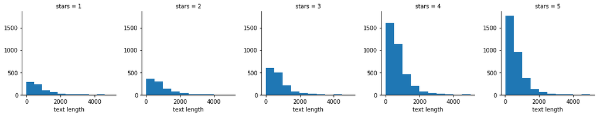

```python
import matplotlib.pyplot as plt
import seaborn as sns
%matplotlib inline

#Use FacetGrid from the seaborn library to create a grid of 5 histograms of text length based off of the star ratings.

g = sns.FacetGrid(yelp,col='stars')
g.map(plt.hist,'text length')
```

Create a countplot of the number of occurrences for each type of star rating.

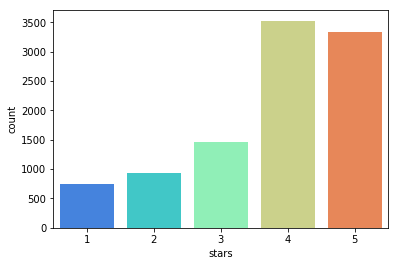

```python
sns.countplot(x='stars',data=yelp,palette='rainbow')
```

```python
yelp.corr()
```

|  | stars | cool | useful | funny | text length |
| --- | --- | --- | --- | --- | --- |
| stars | 1.000000 | 0.052555 | -0.023479 | -0.061306 | -0.114664 |
| cool | 0.052555 | 1.000000 | 0.887102 | 0.764342 | 0.241447 |
| useful | -0.023479 | 0.887102 | 1.000000 | 0.723406 | 0.293975 |
| funny | -0.061306 | 0.764342 | 0.723406 | 1.000000 | 0.251755 |
| text length | -0.114664 | 0.241447 | 0.293975 | 0.251755 | 1.000000 |

Then use seaborn to create a heatmap based off that .corr() dataframe:

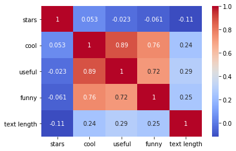

```python
sns.heatmap(yelp.corr(),cmap='coolwarm',annot=True)
```

## Step 3: Data Preprocessing

Let us filter 1 & 5 stars alone and use the data to build a model.

Create a dataframe called yelp_class that contains the columns of yelp dataframe but for only the 1 or 5 star reviews.

```python
yelp_class = yelp[(yelp.stars==1) | (yelp.stars==5)]
```

Create two objects X and y.

X will be the 'text' column of yelp_class (input data)

y will be the 'stars' column of yelp_class. (Target label to be predicted)

```python
X = yelp_class['text']
y = yelp_class['stars']
```

Import CountVectorizer and create a CountVectorizer object.

```python
from sklearn.feature_extraction.text import CountVectorizer
cv = CountVectorizer()
X = cv.fit_transform(X)
```

## Step 4: Train & Test Data Preparation

Let's split our data into training and testing data.

Use train_test_split to split up the data into X_train, X_test, y_train, y_test. Use test_size=0.3 and random_state=101

```python
from sklearn.model_selection import train_test_split
X_train, X_test, y_train, y_test = train_test_split(X, y,test_size=0.3,random_state=101)
```

## Step 5: Build (Training) the Model

Import MultinomialNB, create an instance and fit using train data

```python
from sklearn.naive_bayes import MultinomialNB
nb = MultinomialNB()
nb.fit(X_train,y_train)
```

```
MultinomialNB(alpha=1.0, class_prior=None, fit_prior=True)
```

## Step 6: Predictions and Evaluations

Use the predict method off of nb to predict labels from X_test.

Create a confusion matrix and classification report using these predictions and y_test.

```python
predictions = nb.predict(X_test)

from sklearn.metrics import confusion_matrix,classification_report
print(confusion_matrix(y_test,predictions))
print('\n')
print(classification_report(y_test,predictions))
```

```
[[159  69]
 [ 22 976]]


             precision    recall  f1-score   support

          1       0.88      0.70      0.78       228
          5       0.93      0.98      0.96       998

avg / total       0.92      0.93      0.92      1226
```

The model built seems to classify the reviews to 5 and 1 star correctly with accuracy of 93%